# Лабораторная работа

Номер 6

Андрюшин Н. С.

Российский университет дружбы народов, Москва, Россия

# Информация

## Докладчик

- Андрюшин Никита Сергеевич
- Студент
- Российский университет дружбы народов

## Цель работы

Изучение принципов распределения и настройки адресного пространства на устройствах сети

# Выполнение теоретической части. IPv4

## Задание 1

1. Задана IPv4-сеть 172.16.20.0/24. Для заданной сети определите префикс, маску, broadcast-адрес, число возможных подсетей, диапазон адресов узлов. Разбейте сеть на 3 подсети с максимально возможным числом адресов узлов 126, 62, 62 соответственно.

## Задание 2

2. Задана сеть 10.10.1.64/26. Для заданной сети определите префикс, маску, broadcast-адрес, число возможных подсетей, диапазон адресов узлов. Выделите в этой сети подсеть на 30 узлов. Запишите характеристики для выделенной подсети.

## Решение

Длина префикса – 26, полный адрес сети – 10.10.1.64/26  
Маска – 255.255.255.192  
Broadcast-адрес – 10.10.1.127  
Число возможных подсетей – 2^4 = 16  
Диапазон адресов узлов – 10.10.1.65-10.10.1.126

Разбивка по подсетям:  
Итого имеем сеть 10.10.1.64/27, с диапазоном для адресов узлов равным 10.10.1.65-10.10.1.94. Длина префикса – 27. Маска – 255.255.255.224. Broadcast адрес - 10.10.1.95. Максимальное количество подсетей - если иметь ввиду максимальное число подсетей, на которое можно разбить сеть, то это 2^3 = 8.

## Задание 3

3. Задана сеть 10.10.1.0/26. Для этой сети определите префикс, маску, broadcast адрес, число возможных подсетей, диапазон адресов узлов. Выделите в этой сети подсеть на 14 узлов. Запишите характеристики для выделенной подсети.

## Решение

Длина префикса – 26, полный адрес сети – 10.10.1.0/26  
Маска – 255.255.255.192  
Broadcast-адрес – 10.10.1.63  
Число возможных подсетей – 2^4 = 16  
Диапазон адресов узлов – 10.10.1.1-10.10.1.62

Разбивка по подсетям:  
Итого имеем сеть 10.10.1.0/28, с диапазоном для адресов узлов равным 10.10.1.1-10.10.1.14. Длина префикса – 28. Маска – 255.255.255.240. Broadcast адрес - 10.10.1.15. Максимальное количество подсетей - если иметь ввиду максимальное число подсетей, на которое можно разбить сеть, то это 2^2 = 4.

# Выполнение теоретической части. IPv6

## Задание 1

1. Задана сеть 2001:db8:c0de::/48. Охарактеризуйте адрес, определите маску, префикс, диапазон адресов для узлов сети (краевые значения). Разбейте сеть на 2 подсети двумя способами — с использованием идентификатора подсети и с использованием идентификатора интерфейса. Поясните предложенные вами варианты разбиения.

## Решение

Адрес сети зарезервирован для документации и примеров. Маска – FFFF:FFFF:FFFF:0000:0000:0000:0000:0000. Диапазон устройств - 2001:db8:c0de::- 2001:db8:c0de:ffff:ffff:ffff:ffff:ffff.

Разбиение сетей:  
По ИД подсети:  
1. 2001:db8:c0de:0001::/64  
2. 2001:db8:c0de:0002::/64  
Здесь дробление происходит путём использования зарезервированных под подсети битов с 49 по 64.

По ИД интерфейса  
1. 2001:db8:c0de:0000:1000::/68  
2. 2001:db8:c0de:0000:2000::/68  
Здесь дробление происходит путём урезания полубайта (4 бит) у адреса узла.

## Задание 2

2. Задана сеть 2a02:6b8::/64. Охарактеризуйте адрес, определите маску, префикс, диапазон адресов для узлов сети (краевые значения). Разбейте сеть на 2 подсети двумя способами — с использованием идентификатора подсети и с использованием идентификатора интерфейса. Поясните предложенные вами варианты разбиения.

## Решение

Глобальный адрес. Маска – FFFF:FFFF:FFFF: FFFF:0000:0000:0000:0000. Диапазон устройств - 2a02:6b8::-2a02:6b8:0000:0000:ffff:ffff:ffff:ffff.

Разбиение сетей:  
По ИД подсети:  
3. 2a02:6b8:0000:0001::/64  
4. 2a02:6b8:0000:0002::/64  
Здесь дробление происходит путём использования зарезервированных под подсети битов с 49 по 64.

По ИД интерфейса  
3. 2a02:6b8:0000:0000:1000::/68  
4. 2a02:6b8:0000:0000:2000::/68  
Здесь дробление происходит путём урезания полубайта (4 бит) у адреса узла.

# Выполнение практической части

## Топология сети в GNS3

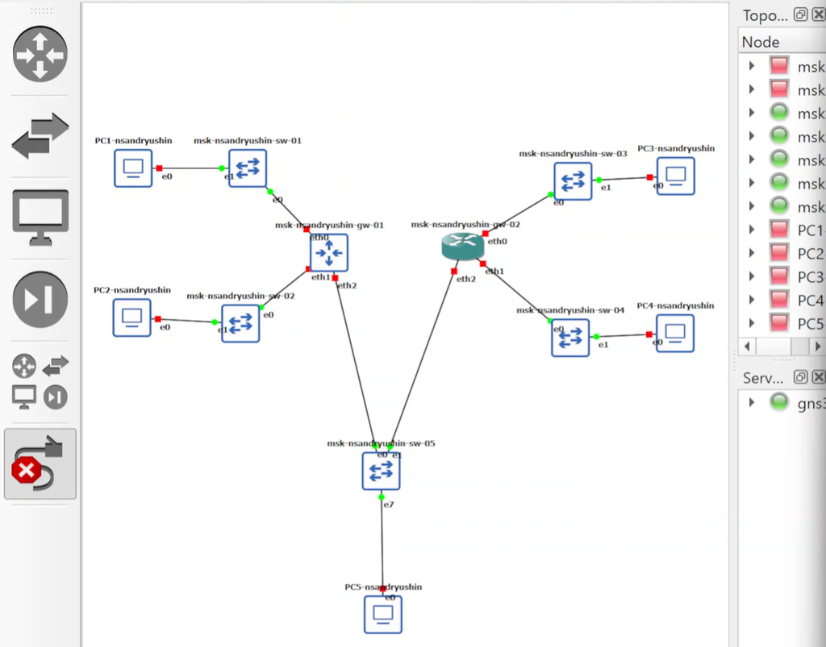

Топология сети в GNS3

## Запуск захвата трафика на интерфейсе сервера

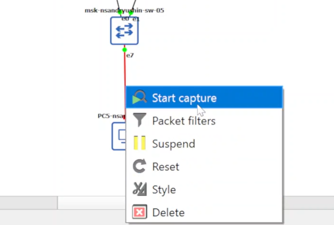

Запуск захвата трафика на интерфейсе сервера

## Настройка IP-адресации на PC1

[figure not shown]

Настройка IP-адресации на PC1

## Настройка IP-адресации на PC2

[figure not shown]

Настройка IP-адресации на PC2

## Настройка IPv4-адресации на сервере

[figure not shown]

Настройка IPv4-адресации на сервере

## Проверка конфигурации IP на устройстве PC1

[figure not shown]

Проверка конфигурации IP на устройстве PC1

## Проверка конфигурации IP на устройстве PC2

[figure not shown]

Проверка конфигурации IP на устройстве PC2

## Настройка интерфейсов маршрутизатора FRR

[figure not shown]

Настройка интерфейсов маршрутизатора FRR

## Просмотр текущей конфигурации маршрутизатора FRR

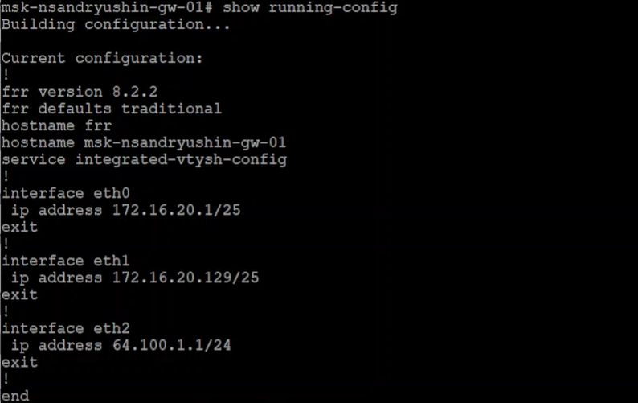

Просмотр текущей конфигурации маршрутизатора FRR

## Статус интерфейсов маршрутизатора FRR

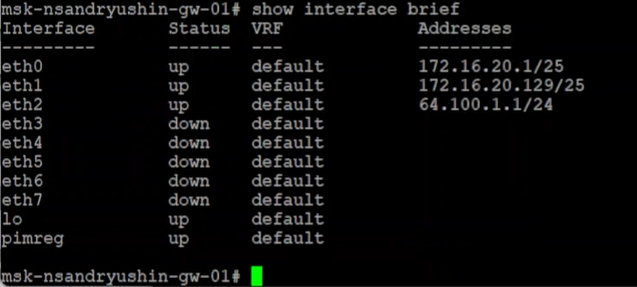

Статус интерфейсов маршрутизатора FRR

## Проверка подключения между PC1 и PC2

[figure not shown]

Проверка подключения между PC1 и PC2

## Проверка подключения от PC1 к серверу

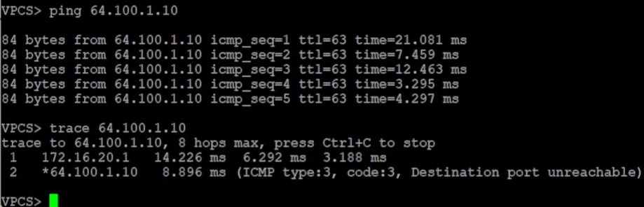

Проверка подключения от PC1 к серверу

## Настройка IPv6-адреса на узле PC3

[figure not shown]

Настройка IPv6-адреса на узле PC3

## Настройка IPv6-адреса на узле PC4

[figure not shown]

Настройка IPv6-адреса на узле PC4

## Настройка адресации IPv6 на сервере

[figure not shown]

Настройка адресации IPv6 на сервере

## Просмотр конфигурации сетевых интерфейсов на PC3

[figure not shown]

Просмотр конфигурации сетевых интерфейсов на PC3

## Просмотр конфигурации сетевых интерфейсов на PC4

[figure not shown]

Просмотр конфигурации сетевых интерфейсов на PC4

## Первоначальная настройка маршрутизатора VyOS: изменение имени хоста

[figure not shown]

Первоначальная настройка маршрутизатора VyOS: изменение имени хоста

## Настройка IPv6-адресации интерфейсов на маршрутизаторе VyOS

[figure not shown]

Настройка IPv6-адресации интерфейсов на маршрутизаторе VyOS

## Проверка конфигурации интерфейсов на маршрутизаторе msk-nsandryushin-gw-02

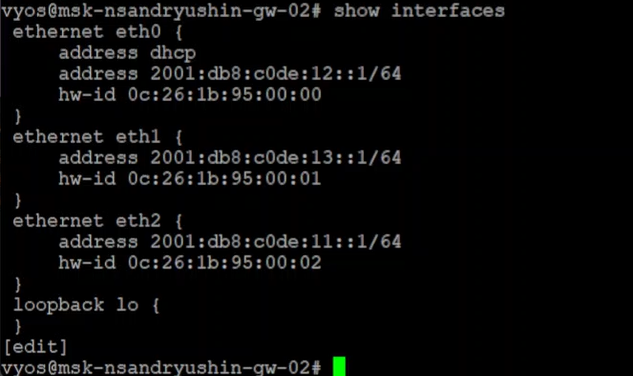

Проверка конфигурации интерфейсов на маршрутизаторе msk-nsandryushin-gw-02

## Проверка доступности PC4 с узла PC3

[figure not shown]

Проверка доступности PC4 с узла PC3

## Проверка связи PC3 с IPv6-интерфейсом сервера

[figure not shown]

Проверка связи PC3 с IPv6-интерфейсом сервера

## Проверка связи PC1 с сервером и попытка обращения к IPv6

[figure not shown]

Проверка связи PC1 с сервером и попытка обращения к IPv6

## Проверка недоступности IPv4-сети с узла PC3

[figure not shown]

Проверка недоступности IPv4-сети с узла PC3

## Настройка сервера и проверка доступа к обеим подсетям

[figure not shown]

Настройка сервера и проверка доступа к обеим подсетям

## Захват трафика IPv4 (ICMP и ARP) в Wireshark

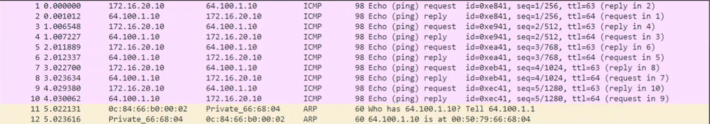

Захват трафика IPv4 (ICMP и ARP) в Wireshark

## Захват трафика IPv6 (ICMPv6 и ND) в Wireshark

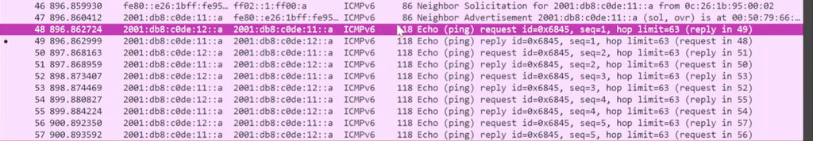

Захват трафика IPv6 (ICMPv6 и ND) в Wireshark

## Детальный просмотр последовательности пакетов IPv4

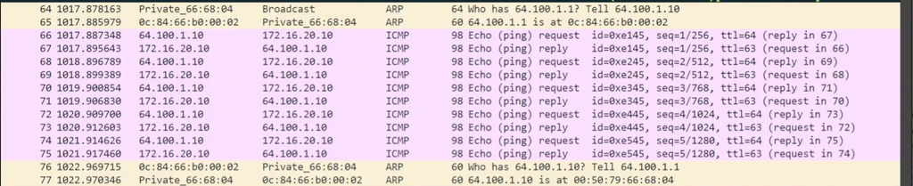

Детальный просмотр последовательности пакетов IPv4

## Детальный просмотр последовательности пакетов IPv6

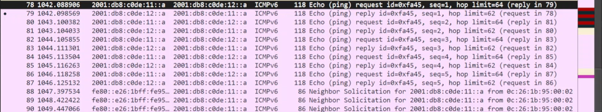

Детальный просмотр последовательности пакетов IPv6

# Самостоятельная работа

## Таблица адресации для самостоятельного задания

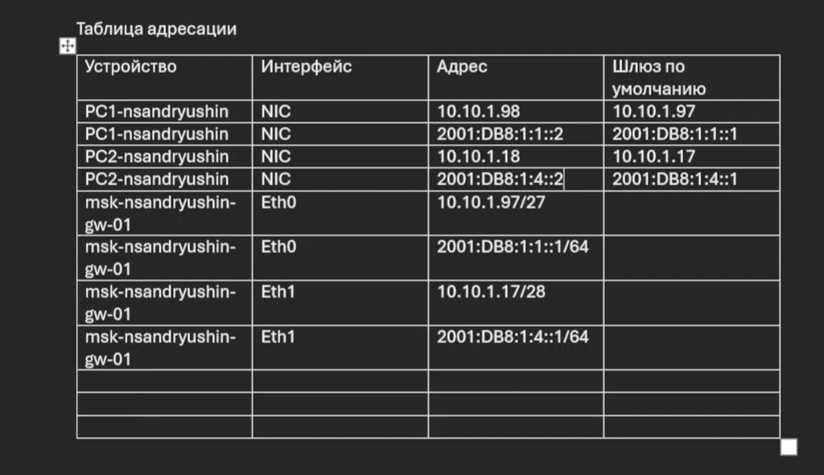

Таблица адресации для самостоятельного задания

## Топология сети для самостоятельного выполнения

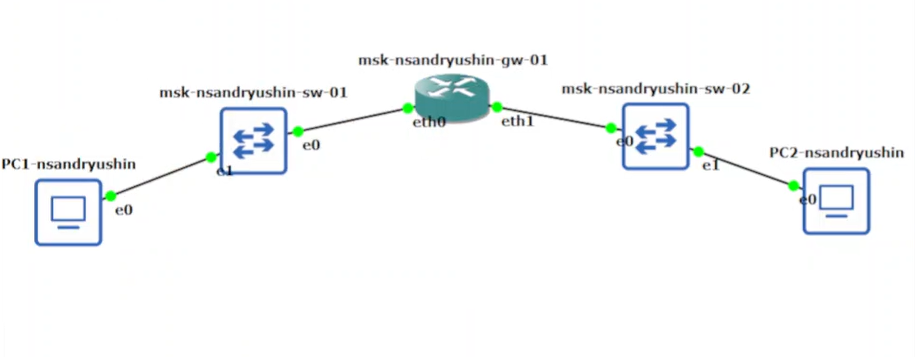

Топология сети для самостоятельного выполнения

## Настройка адресации на PC1

[figure not shown]

Настройка адресации на PC1